# DataMining_BackPain_Project

#### Accessing the Fit of Baseline Models with Validation Test

```r
validation.predict.rf <- predict(fit.rf, ValidationSet)
ConfMat.RF <- confusionMatrix(validation.predict.rf, ValidationSet$PainDiagnosis)
ConfMat.RF$overall['Accuracy']
```

```
##  Accuracy
## 0.9411765
```

```r
validation.predict.boosting <- predict(fit.boosting, ValidationSet)
ConfMat.Boosting <- confusionMatrix(validation.predict.boosting, ValidationSet$PainDiagnosis)
ConfMat.Boosting$overall['Accuracy']
```

```
##  Accuracy
## 0.9411765
```

```r
validation.predict.svm <- predict(fit.svmRadial, ValidationSet)
ConfMat.svm <- confusionMatrix(validation.predict.svm, ValidationSet$PainDiagnosis)
ConfMat.svm$overall['Accuracy']
```

```
##  Accuracy
## 0.9264706
```

```r
validation.predict.bagging <- predict(fit.bagging, ValidationSet)
ConfMat.bagging <- confusionMatrix(validation.predict.bagging, ValidationSet$PainDiagnosis)
ConfMat.bagging$overall['Accuracy']
```

```
##  Accuracy
## 0.9264706
```

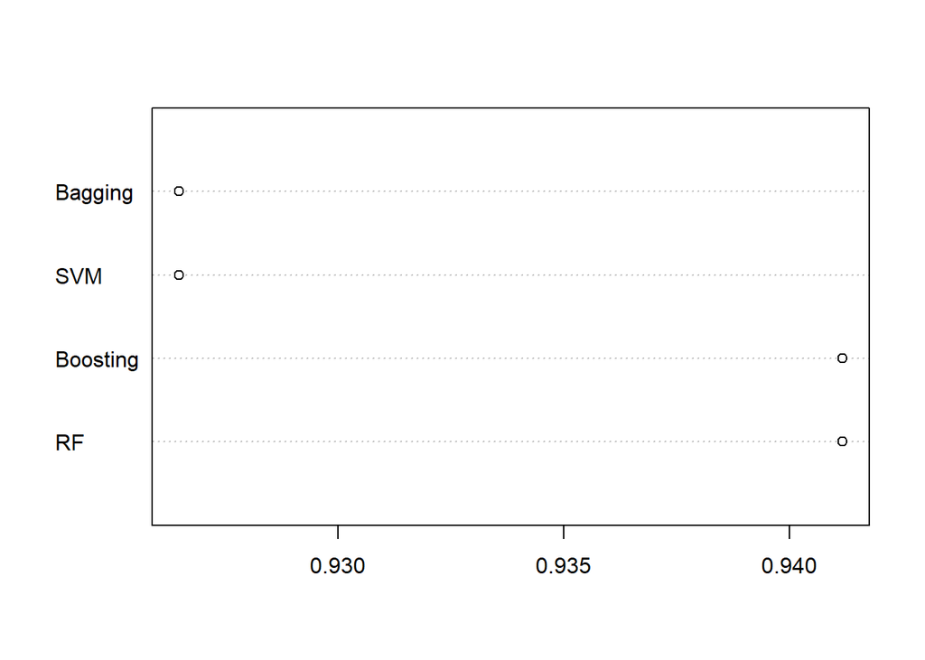

```r
Validation_Result <- c(ConfMat.RF$overall['Accuracy'] , ConfMat.Boosting$overall['Accuracy'],
                       ConfMat.svm$overall['Accuracy'] , ConfMat.bagging$overall['Accuracy'])
Validation_Method <- c("RF", "Boosting", "SVM", "Bagging")
dotchart(Validation_Result,labels=Validation_Method)
```

In my Baselines models, I have used 4 different methods which are Random Forest, Bagging, Boosting, and SVM. Looking at the Accuracy metrics for Training Set, SVM performs the best among methods, Boosting and Random Forest have quite similar accuracy. However, Random Forest seems to have the lowest variance.

## 4.2 Improve Accuracy with Variable Selection (VarImp), Standardized Data, and PCA.

```r
Trainset_Select <- TrainSet
```

From the Variable Selection step above using VarImp method, I could find out some unimportant variables. In other word, I will not contribute any information to to tree-based model in model building. Moreover, I will also eliminate some unwanted noise in building model.

```r
Trainset_Select$Gender <- NULL
Trainset_Select$Criterion32 <- NULL
Trainset_Select$Criterion20 <- NULL
Trainset_Select$SurityRating <- NULL
```

```r
preProcess2 <- preProcess(Trainset_Select[,-1], method= c("center", "scale", "pca"))
Trainset_Select[,-1] <- predict(preProcess2, Trainset_Select[,-1])
```

Standardize Data will make the attributes have Mean of 0, Variance of 1. In other words, Standardized data will treat all the variables in our data equally. It also supports PCA.

PCA is a multivariate technique to deal with highly correlated variable, and to perform the dimensionality reduction with minimal loss of the information. PCA will extract the important information of the whole dataset and will express with fewer new variables. After performing the EDA of the dataset using Pearson Correlation for Continuous Variables, I have figured out that there are some highly correlated variables so It may useful to apply PCA to data.

#### preProcess Summary

```r
preProcess2
```

```
## Created from 275 samples and 27 variables
##
## Pre-processing:
##   - centered (12)
##   - ignored (15)
##   - principal component signal extraction (12)
##   - scaled (12)
##
## PCA needed 9 components to capture 95 percent of the variance
```

```r
set.seed(123)
trainControl <- trainControl(method="repeatedcv", number=10, repeats=3)
metric <- "Accuracy"
```

#### Random Forest

```r
set.seed(123)
fit.rf.select <- train(PainDiagnosis~., data=Trainset_Select, method="rf", metric=metric, trControl=trainControl)
```

#### Bagging (treebag)

```r
set.seed(123)
fit.bagging.select <- train(PainDiagnosis~., data=Trainset_Select, method="treebag", metric=metric, trControl=trainControl)
```

#### SVM

```r
set.seed(123)
fit.svmRadial.select <- train(PainDiagnosis~., data=Trainset_Select, method="svmPoly", metric=metric,trControl=trainControl)
```

#### Boosting

```r
fit.boosting.select <- train(PainDiagnosis~., data=Trainset_Select, method="adaboost", metric=metric, trControl=trainControl)
```

#### Result of Traning Set

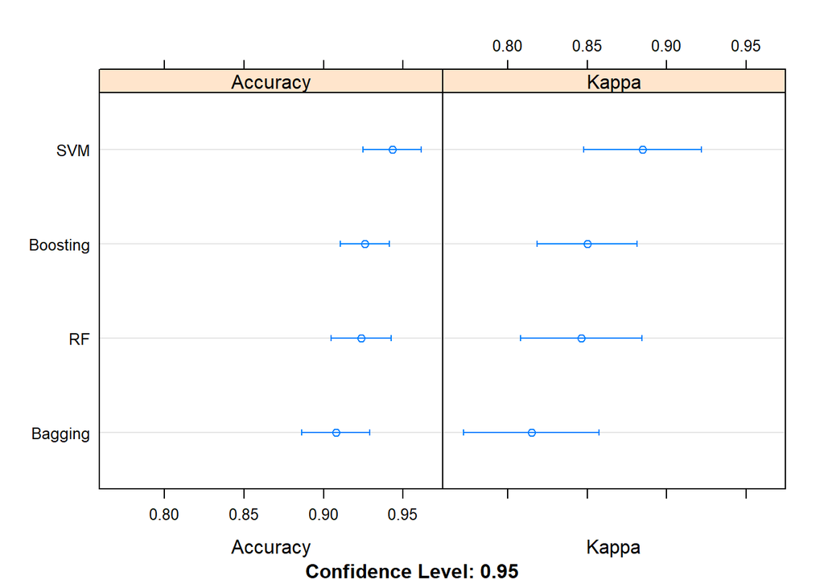

```r
results.select <- resamples(list(RF = fit.rf.select, Bagging = fit.bagging.select, SVM= fit.svmRadial.select, Boosting= fit.boosting.select))
dotplot(results.select)
```

#### Test Pre-Process with Validation Test

```r
ValidationSet.Select <- ValidationSet
```

```r
ValidationSet.Select$Gender <- NULL
ValidationSet.Select$Criterion32 <- NULL
ValidationSet.Select$Criterion20 <- NULL
ValidationSet.Select$SurityRating <- NULL
```

```r
ValidationSet.Select[,-1] <- predict(preProcess2, ValidationSet.Select[,-1])
```

```r
validation.predict.rf.select <- predict(fit.rf.select, ValidationSet.Select)
ConfMat.RF.select <- confusionMatrix(validation.predict.rf.select, ValidationSet.Select$PainDiagnosis)
ConfMat.RF.select$overall['Accuracy']
```

```
##  Accuracy
## 0.9264706
```

```r
validation.predict.boosting.select <- predict(fit.boosting.select, ValidationSet.Select)
ConfMat.Boosting.select <- confusionMatrix(validation.predict.boosting.select, ValidationSet.Select$PainDiagnosis)
ConfMat.Boosting.select$overall['Accuracy']
```

```
##  Accuracy
## 0.9264706
```

```r
validation.predict.svm.select <- predict(fit.svmRadial.select, ValidationSet.Select)
ConfMat.svm.select <- confusionMatrix(validation.predict.svm.select, ValidationSet.Select$PainDiagnosis)
ConfMat.svm.select$overall['Accuracy']
```

```
##  Accuracy
## 0.9117647
```

```r
validation.predict.bagging.select <- predict(fit.bagging.select, ValidationSet.Select)
ConfMat.bagging.select <- confusionMatrix(validation.predict.bagging.select, ValidationSet.Select$PainDiagnosis)
ConfMat.bagging.select$overall['Accuracy']
```

```
##  Accuracy
## 0.8970588
```

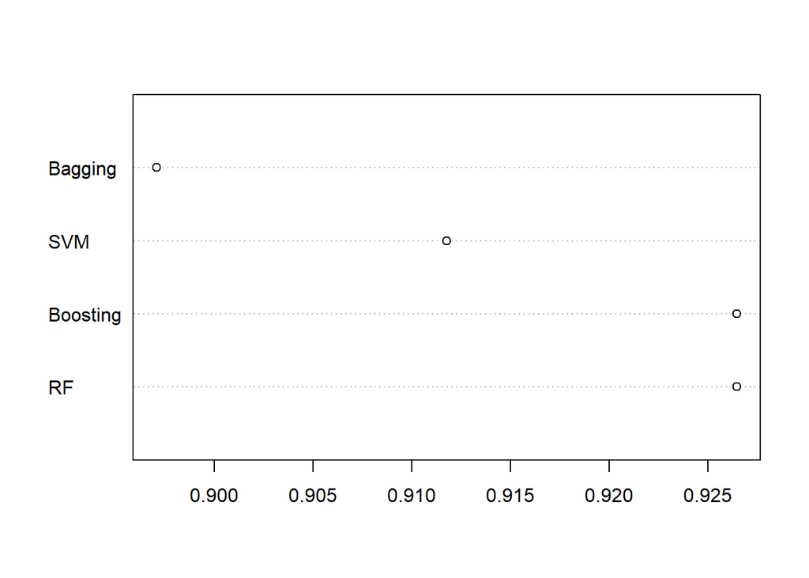

```r
Validation_Result.select <- c(ConfMat.RF.select$overall['Accuracy'] , ConfMat.Boosting.select$overall['Accuracy'],
                       ConfMat.svm.select$overall['Accuracy'] , ConfMat.bagging.select$overall['Accuracy'])
Validation_Method.select <- c("RF", "Boosting", "SVM", "Bagging")
dotchart(Validation_Result.select,labels=Validation_Method.select)
```

# 5. Tuning Parameters.

From the Baseline Models, we would choose the “best” model in term of Bias-Variance Tradeoff to tune the parameters. Tuning Parameters is to find the optimal parameters for algorithm to make the powerful machine learning perform even better. Each machine learning will have unique parameters to tune. The algorithms are parameterized are expected to perform better.

```r
# Random Search
trainControl <- trainControl(method="repeatedcv", number=10, repeats=3, search="random",summaryFunction = twoClassSummary,classProbs = TRUE)
set.seed(123)
metric <- "ROC"
mtry <- sqrt(ncol(Trainset_Select[,-1]))
rfRandom <- train(PainDiagnosis~., data=Trainset_Select, method="rf", metric=metric, tuneLength=15, trControl=trainControl)
```

```r
rfRandom
```

```
## Random Forest
##
## 275 samples
##  27 predictor
##   2 classes: 'Nociceptive', 'Neuropathic'
##
## No pre-processing
## Resampling: Cross-Validated (10 fold, repeated 3 times)
## Summary of sample sizes: 248, 248, 248, 247, 247, 247, ...
## Resampling results across tuning parameters:
##
##   mtry  ROC        Sens       Spec
##    2    0.9768946  0.9711111  0.8512821
##    5    0.9773219  0.9600000  0.9072650
##   18    0.9761610  0.9400000  0.9149573
##   20    0.9734900  0.9400000  0.9149573
##   23    0.9741026  0.9355556  0.9149573
##   24    0.9734900  0.9311111  0.9123932
##   25    0.9715171  0.9244444  0.9123932
##   30    0.9700712  0.9133333  0.9123932
##   34    0.9688533  0.9177778  0.9098291
##   38    0.9668020  0.9000000  0.9098291
##   39    0.9627707  0.9000000  0.9072650
##   41    0.9650142  0.8977778  0.9096154
##   42    0.9616311  0.9088889  0.9070513
##
## ROC was used to select the optimal model using the largest value.
## The final value used for the model was mtry = 5.
```

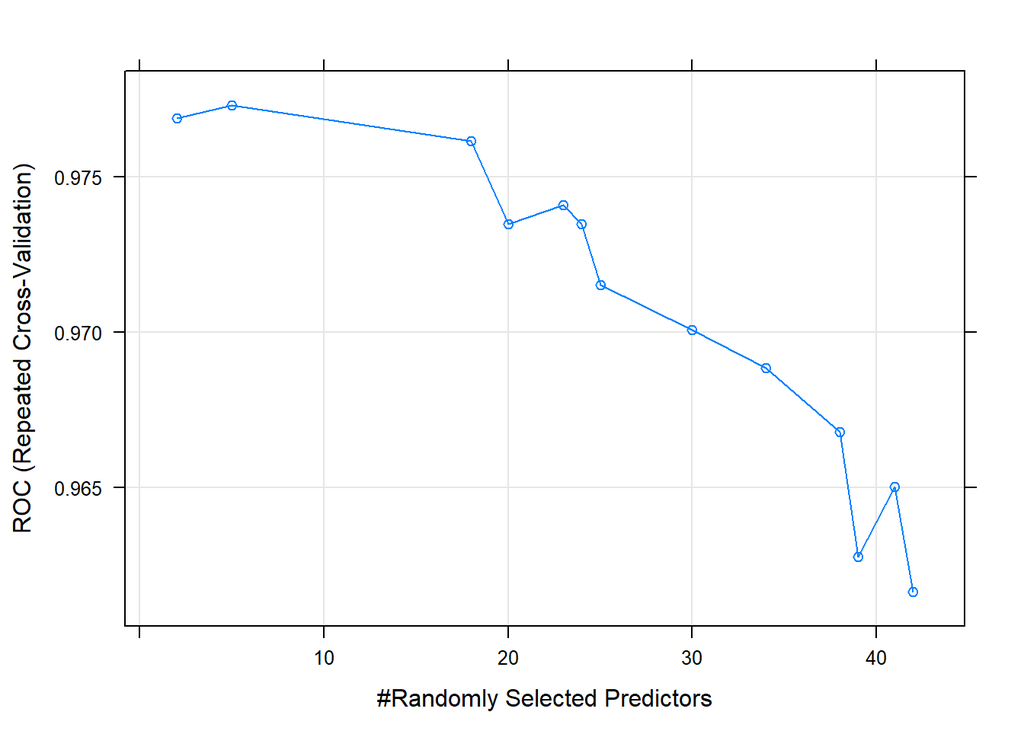

```r
plot(rfRandom)
```

```r
print(rfRandom)
```

```
## Random Forest
##
## 275 samples
##  27 predictor
##   2 classes: 'Nociceptive', 'Neuropathic'
##
## No pre-processing
## Resampling: Cross-Validated (10 fold, repeated 3 times)
## Summary of sample sizes: 248, 248, 248, 247, 247, 247, ...
## Resampling results across tuning parameters:
##
##   mtry  ROC        Sens       Spec
##    2    0.9768946  0.9711111  0.8512821
##    5    0.9773219  0.9600000  0.9072650
##   18    0.9761610  0.9400000  0.9149573
##   20    0.9734900  0.9400000  0.9149573
##   23    0.9741026  0.9355556  0.9149573
##   24    0.9734900  0.9311111  0.9123932
##   25    0.9715171  0.9244444  0.9123932
##   30    0.9700712  0.9133333  0.9123932
##   34    0.9688533  0.9177778  0.9098291
##   38    0.9668020  0.9000000  0.9098291
##   39    0.9627707  0.9000000  0.9072650
##   41    0.9650142  0.8977778  0.9096154
##   42    0.9616311  0.9088889  0.9070513
##
## ROC was used to select the optimal model using the largest value.
## The final value used for the model was mtry = 5.
```

For Random Forest model, I would tune the “mtry” which is the random selected Predictors. In others words, my tuning parameter is the number of selected predictor at each split. From the result of tuning parameter for Random Forest, the best “mtry” for my model on Training Data is at 5 because it has the highest ROC of 97.73% for Training Data

# 6. Test the Final model with Test Data

```r
TestSet$Gender <- NULL
TestSet$Criterion32 <- NULL
TestSet$Criterion20 <- NULL
TestSet$SurityRating <- NULL
```

- Eliminate the unimportant variables found from Variable Selection steps above.

```r
TestSet[,-1] <- predict(preProcess2, TestSet[,-1])
```

- PreProcess the Data similar to previous step.

```r
TestSet.Predict <- predict(rfRandom, TestSet)
Final <- confusionMatrix(TestSet.Predict, TestSet$PainDiagnosis)
Final
```

```
## Confusion Matrix and Statistics
##
##              Reference
## Prediction    Nociceptive Neuropathic
##   Nociceptive          19           1
##   Neuropathic           1          16
##
##                Accuracy : 0.9459
##                  95% CI : (0.8181, 0.9934)
##     No Information Rate : 0.5405
##     P-Value [Acc > NIR] : 6.688e-08
##
##                   Kappa : 0.8912
##  Mcnemar's Test P-Value : 1
##
##             Sensitivity : 0.9500
##             Specificity : 0.9412
##          Pos Pred Value : 0.9500
##          Neg Pred Value : 0.9412
##              Prevalence : 0.5405
##          Detection Rate : 0.5135
##    Detection Prevalence : 0.5405
##       Balanced Accuracy : 0.9456
##
##        'Positive' Class : Nociceptive
##
```

- Predict the Test Set using final model and accessing the accuracy metric.

Finally, I applied my “parameterized final model” to predict for Test Data and accessing the Performance Metrics by Confusion Matrix and ROC curve. Looking at the Confusion Matrix, Accuracy is 94.59%, which means my Final Model correctly classified 35 observation out of 37 observations in Test Data without looking at Test Data in advanced. We have balanced Responses (Nociceptive, Neuropathic) so the Balanced Accuracy is quite high as expected which is 94.56%. The Sensitivity is 95.00%, which means 19 out 20 observations were correctly classified as Nociceptive. Similarly, The Specificity is 94.12%, which means 16 out of 17 observations from Neuropathic were correctly classified.

We have balanced class data, besides the Accuracy, I will access other performance metrics such as Balanced Accuracy, Sensitivity and Specificity. Because of Binary Classification, I would pay more attention on ROC Curve to have a deeper look into Sensitivity and Specificity.

#### Convert Predicted Values of Test Set to Probablity for ROC curve.

```r
Pred_prob <-  predict(rfRandom, TestSet, type = "prob")
Pred_prob_Neuro <-  as.data.frame(Pred_prob)
Pred_prob_Neuro <- Pred_prob_Neuro[,2]
```

```r
ROC_Actual = ifelse(TestSet$PainDiagnosis == "Nociceptive",0,1)
```

```r
library(ROCR)
predobj<-prediction(as.numeric(Pred_prob_Neuro), as.numeric(ROC_Actual))
```

```r
perf <- performance(predobj,"tpr","fpr")
```

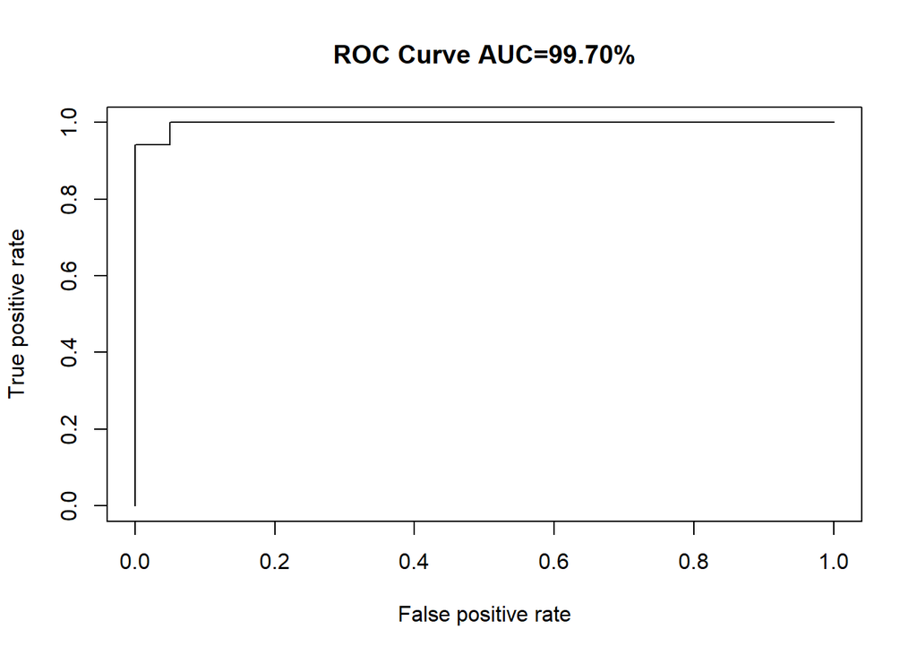

```r
plot(perf, main = "ROC Curve AUC=99.70%")
```

```r
auc2 <- performance(predobj, measure = "auc")
auc2@y.values[[1]]
```

```
## [1] 0.9970588
```

```r
cutoffs <- data.frame(cut=perf@alpha.values[[1]], fpr=perf@x.values[[1]],
                      tpr=perf@y.values[[1]])
head(subset(cutoffs, tpr >= 0.9))
```

```
##      cut  fpr       tpr
## 17 0.538 0.00 0.9411765
## 18 0.518 0.05 0.9411765
## 19 0.486 0.05 1.0000000
## 20 0.450 0.10 1.0000000
## 21 0.294 0.15 1.0000000
## 22 0.274 0.20 1.0000000
```

```r
# Maximize Sum of Specificity and Sensitivity find optimal Threshold.
cutoffs$Sum <- cutoffs$tpr - cutoffs$fpr
head(subset(cutoffs, Sum >= 0.95))
```

```
##      cut  fpr tpr  Sum
## 19 0.486 0.05   1 0.95
```

```r
perf2 <- performance(predobj, "sens","spec")
t.ind <- which.max(unlist(perf2@x.values) + unlist(perf2@y.values))
tau   <- unlist(perf2@alpha.values)[t.ind]
tau
```

```
## [1] 0.486
```

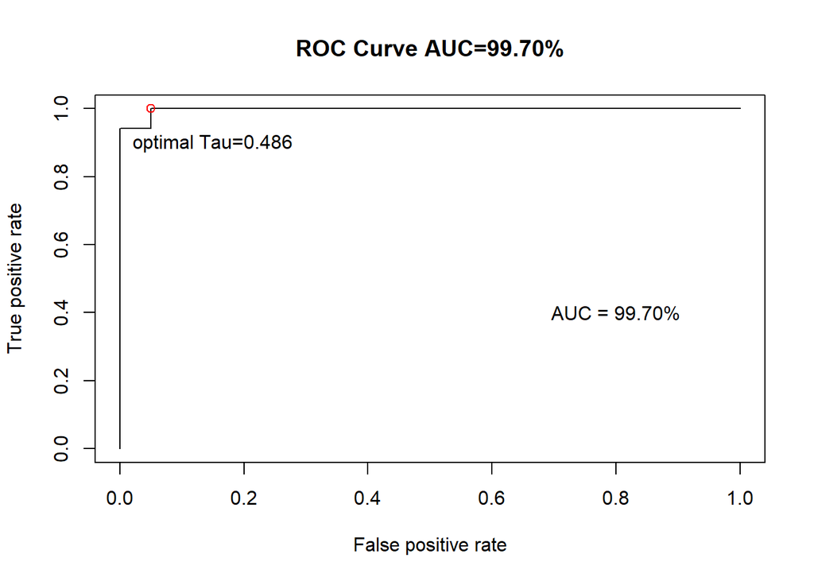

```r
plot(perf, main = "ROC Curve AUC=99.70%")
points(0.05, y =1, type = "p", col="red")
text(0.8, 0.4, "AUC = 99.70%")
text(0.15, 0.9, "optimal Tau=0.486")
```